# Fraud_Detection_online_final

```python
### imports all the required libraries for building the fraud detection system

import mysql.connector
import pandas as pd
import numpy as np
import matplotlib.pyplot as plt
import seaborn as sns
import warnings
warnings.filterwarnings("ignore")

from sklearn.model_selection import train_test_split, StratifiedKFold, cross_val_score, GridSearchCV
from sklearn.metrics import classification_report, accuracy_score, precision_score, recall_score, f1_score, roc_auc_score

from sklearn.linear_model import LogisticRegression
from sklearn.ensemble import RandomForestClassifier
from xgboost import XGBClassifier

from imblearn.pipeline import Pipeline
from imblearn.over_sampling import SMOTE

import joblib
```

```python
##DATABASE CONNECTION

conn = mysql.connector.connect(
    host='localhost',
    user='root',
    password='abc123',
    database='fraud_db'
)

query = "SELECT * FROM transactions_fraud"
df = pd.read_sql(query, conn)
```

```python
## Initial data inspection (EDA)

df.head()
```

|  | transaction_id | customer_id | device_id | merchant_id | timestamp | amount | payment_method | is_international | merchant_category | ip_address_risk_score | ... | location_change_flag | authentication_method | otp_success_rate_customer | past_fraud_count_customer | past_disputes_customer | merchant_historical_fraud_rate | hour_of_day | day_of_week | is_weekend | is_fraud |
| --- | --- | --- | --- | --- | --- | --- | --- | --- | --- | --- | --- | --- | --- | --- | --- | --- | --- | --- | --- | --- | --- |
| 0 | 1 | 1357 | 20937 | 720 | 1/18/24 19:23 | 18780.52 | WALLET | 0 | Travel | 0.243550 | ... | 0 | NONE | 0.769328 | 1 | 2 | 0.069502 | 19 | 3 | 0 | 0 |
| 1 | 2 | 4095 | 29542 | 764 | 3/30/24 2:22 | 18955.06 | CARD | 0 | Electronics | 0.119761 | ... | 1 | OTP | 0.468411 | 1 | 1 | 0.010010 | 2 | 5 | 1 | 0 |
| 2 | 3 | 3618 | 25236 | 671 | 1/4/24 17:26 | 10743.34 | UPI | 0 | Fashion | 0.565367 | ... | 0 | PIN | 0.464356 | 0 | 1 | 0.118434 | 17 | 3 | 0 | 0 |
| 3 | 4 | 2755 | 29904 | 624 | 1/27/24 16:00 | 5054.75 | CARD | 0 | Utilities | 0.843842 | ... | 0 | PIN | 0.635799 | 0 | 3 | 0.114947 | 16 | 5 | 1 | 0 |
| 4 | 5 | 2732 | 24151 | 501 | 2/20/24 23:14 | 14799.50 | CARD | 0 | Gaming | 0.202402 | ... | 0 | OTP | 0.684301 | 2 | 0 | 0.014550 | 23 | 1 | 0 | 0 |

5 rows × 25 columns

```python
df.info()
```

```
<class 'pandas.core.frame.DataFrame'>
RangeIndex: 50000 entries, 0 to 49999
Data columns (total 25 columns):
 #   Column                          Non-Null Count  Dtype
---  ------                          --------------  -----
 0   transaction_id                  50000 non-null  int64
 1   customer_id                     50000 non-null  int64
 2   device_id                       50000 non-null  int64
 3   merchant_id                     50000 non-null  int64
 4   timestamp                       50000 non-null  object
 5   amount                          50000 non-null  float64
 6   payment_method                  50000 non-null  object
 7   is_international                50000 non-null  int64
 8   merchant_category               50000 non-null  object
 9   ip_address_risk_score           50000 non-null  float64
```

[output cut: 17 more lines]

```python
print("Duplicates:", df.duplicated().sum())
```

```
Duplicates: 0
```

```python
fraudulent_transactions = df[df['is_fraud'] == 1]
legitimate_transactions = df[df['is_fraud'] == 0]

print(f"Number of fraudulent transactions: {len(fraudulent_transactions)}")
print(f"Number of legitimate transactions: {len(legitimate_transactions)}")
```

```
Number of fraudulent transactions: 5028
Number of legitimate transactions: 44972
```

```python
#Fraud status percentage
round(df['is_fraud'].value_counts()[1]/df.shape[0]*100,2)
```

```
np.float64(10.06)
```

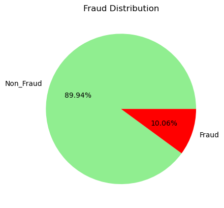

```python
df["is_fraud"].value_counts().plot(
    kind='pie',
    autopct='%1.2f%%',
    labels=['Non_Fraud','Fraud'],
    colors=['lightgreen','red'],
    title="Fraud Distribution"
)
plt.ylabel("")
plt.show()
```

```
======================================================================
OUTLIER ANALYSIS
======================================================================
                           Feature  Outlier_Count  Outlier_Percentage
12            location_change_flag           4937                9.87
11              device_change_flag           3989                7.98
5                 is_international           1479                2.96
0                   transaction_id              0                0.00
3                      merchant_id              0                0.00
2                        device_id              0                0.00
1                      customer_id              0                0.00
6            ip_address_risk_score              0                0.00
7               device_trust_score              0                0.00
8               txn_count_last_24h              0                0.00
9              avg_amount_last_24h              0                0.00
4                           amount              0                0.00
10      merchant_diversity_last_7d              0                0.00
13       otp_success_rate_customer              0                0.00
14       past_fraud_count_customer              0                0.00
15          past_disputes_customer              0                0.00
16  merchant_historical_fraud_rate              0                0.00
17                     hour_of_day              0                0.00
18                     day_of_week              0                0.00
19                      is_weekend              0                0.00
```

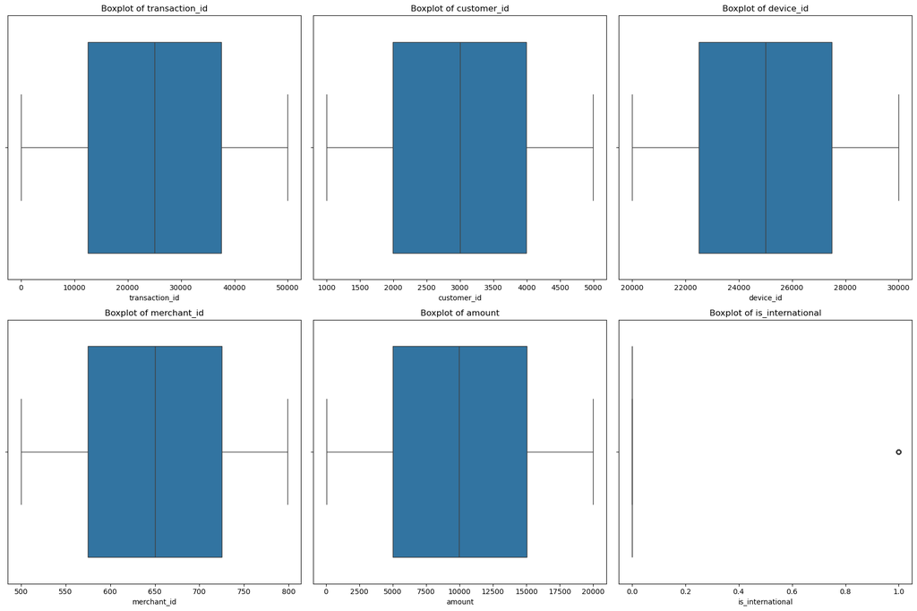

```python
# ============================================================
# OUTLIER ANALYSIS
# ============================================================

import matplotlib.pyplot as plt
import seaborn as sns

# Select numerical columns only
numerical_cols = df.select_dtypes(include=['int64', 'float64']).columns.tolist()

# Remove target column
if 'is_fraud' in numerical_cols:
    numerical_cols.remove('is_fraud')

print("=" * 70)
print("OUTLIER ANALYSIS")
print("=" * 70)

# Summary using IQR
outlier_summary = []

for col in numerical_cols:
    Q1 = df[col].quantile(0.25)
    Q3 = df[col].quantile(0.75)
    IQR = Q3 - Q1

    lower_bound = Q1 - 1.5 * IQR
    upper_bound = Q3 + 1.5 * IQR

    outliers = df[
        (df[col] < lower_bound) |
        (df[col] > upper_bound)
    ].shape[0]

    outlier_summary.append({
        'Feature': col,
        'Outlier_Count': outliers,
        'Outlier_Percentage': round(
            (outliers / len(df)) * 100, 2
        )
    })

outlier_df = pd.DataFrame(outlier_summary)
outlier_df = outlier_df.sort_values(
    by='Outlier_Percentage',
    ascending=False
)

print(outlier_df)

# ------------------------------------------------------------
# Boxplots for Important Numerical Features
# ------------------------------------------------------------
important_features = numerical_cols[:6]

plt.figure(figsize=(18, 12))

for i, col in enumerate(important_features, 1):
    plt.subplot(2, 3, i)
    sns.boxplot(x=df[col])
    plt.title(f'Boxplot of {col}')

plt.tight_layout()
plt.show()
```

```python
##FEATURE ENGINEERING

df['high_amount'] = (df['amount'] > 20000).astype(int)
df['high_ip_risk'] = (df['ip_address_risk_score'] > 0.7).astype(int)
df['high_txn_velocity'] = (df['txn_count_last_24h'] > 5).astype(int)

df['amount_deviation'] = df['amount'] - df['avg_amount_last_24h']
df['customer_risk'] = df['past_fraud_count_customer'] + df['past_disputes_customer']
df['night_transaction'] = df['hour_of_day'].apply(lambda x: 1 if x < 6 else 0)

df['risk_score'] = (
    df['high_amount'] +
    df['high_ip_risk'] +
    df['high_txn_velocity'] +
    df['location_change_flag'] +
    df['is_international']
)
```

```python
# Timestamp handling

df['timestamp'] = pd.to_datetime(df['timestamp'], errors='coerce')
df['hour'] = df['timestamp'].dt.hour
df['day'] = df['timestamp'].dt.day
df['month'] = df['timestamp'].dt.month
df.drop('timestamp', axis=1, inplace=True)
```

```python
# Encoding
df = pd.get_dummies(df, drop_first=True)
```

```python
## Train test split

X = df.drop("is_fraud", axis=1)
y = df["is_fraud"]

X_train, X_test, y_train, y_test = train_test_split(
    X, y,
    test_size=0.2,
    stratify=y,
    random_state=42
)
```

## Multiple machine learning models are defined to compare performance:

Logistic Regression for baseline linear modeling, Random Forest for ensemble-based learning, XGBoost for advanced gradient boosting

```python
models = {
    "Logistic Regression": LogisticRegression(max_iter=1000, class_weight='balanced'),

    "Random Forest": RandomForestClassifier(
        n_estimators=200,
        random_state=42,
        class_weight='balanced'
    ),

    "XGBoost": XGBClassifier(
        n_estimators=300,
        learning_rate=0.05,
        max_depth=6,
        eval_metric='logloss',
        random_state=42
    )
}
```

## TRAIN + TEST EVALUATION

Each model is trained using a pipeline that includes SMOTE for handling class imbalance and the classifier itself. Predictions are made on the test set, and performance is evaluated using F1-score and classification reports. This provides a balanced understanding of precision and recall, which is critical in fraud detection

```python
print("\n" + "="*70)
print("TEST PERFORMANCE (DEFAULT THRESHOLD)")
print("="*70)

trained_pipelines = {}

for name, model in models.items():

    print(f"\nMODEL: {name}")

    pipeline = Pipeline([
        ('smote', SMOTE(random_state=42)),
        ('model', model)
    ])

    pipeline.fit(X_train, y_train)

    y_pred = pipeline.predict(X_test)

    trained_pipelines[name] = pipeline

    print("\nF1 Score:", f1_score(y_test, y_pred))
    print(classification_report(y_test, y_pred))
```

```
======================================================================
TEST PERFORMANCE (DEFAULT THRESHOLD)
======================================================================

MODEL: Logistic Regression

F1 Score: 0.15508513575701796
              precision    recall  f1-score   support

           0       0.90      0.67      0.77      8994
           1       0.10      0.33      0.16      1006

    accuracy                           0.63     10000
   macro avg       0.50      0.50      0.46     10000
weighted avg       0.82      0.63      0.70     10000


MODEL: Random Forest

F1 Score: 0.036273701566364384
              precision    recall  f1-score   support

           0       0.90      0.98      0.94      8994
           1       0.11      0.02      0.04      1006

    accuracy                           0.88     10000
   macro avg       0.50      0.50      0.49     10000
weighted avg       0.82      0.88      0.85     10000


MODEL: XGBoost

F1 Score: 0.059130434782608696
              precision    recall  f1-score   support

           0       0.90      0.99      0.94      8994
           1       0.24      0.03      0.06      1006

    accuracy                           0.89     10000
   macro avg       0.57      0.51      0.50     10000
weighted avg       0.83      0.89      0.85     10000
```

## CROSS VALIDATION

Stratified K-Fold cross-validation is applied to evaluate model stability across multiple data spliT. The weighted F1-score is used as the evaluation metric to account for class imbalance while maintaining fairness across classes.

```python
print("\n" + "="*70)
print("CROSS VALIDATION (LEAKAGE FREE)")
print("="*70)

cv = StratifiedKFold(n_splits=5, shuffle=True, random_state=42)

for name, model in models.items():

    pipeline = Pipeline([
        ('smote', SMOTE(random_state=42)),
        ('model', model)
    ])

    scores = cross_val_score(
        pipeline,
        X,
        y,
        cv=cv,
        scoring='f1_weighted',
        n_jobs=-1
    )

    print(f"\n{name}")
    print("F1 Scores:", scores)
    print("Mean:", scores.mean())
    print("Std:", scores.std())
```

```
======================================================================
CROSS VALIDATION (LEAKAGE FREE)
======================================================================

Logistic Regression
F1 Scores: [0.70818824 0.70050862 0.70366781 0.7082018  0.69777237]
Mean: 0.7036677696673774
Std: 0.0041407250891983575

Random Forest
F1 Scores: [0.84964221 0.84390357 0.84642636 0.84890478 0.84764079]
Mean: 0.8473035415612212
Std: 0.002023677927808169

XGBoost
F1 Scores: [0.85388061 0.85038311 0.8516236  0.85387717 0.85062282]
Mean: 0.8520774632353334
Std: 0.0015285993829990652
```

### GRID SEARCH (XGBOOST)

Hyperparameter tuning is performed on the XGBoost model using GridSearchCV.

```python
pipeline = Pipeline([
    ('smote', SMOTE(random_state=42)),
    ('model', XGBClassifier(eval_metric='logloss', random_state=42))
])

param_grid = {
    'model__n_estimators': [200, 300],
    'model__max_depth': [4, 6],
    'model__learning_rate': [0.05, 0.1]
}

grid = GridSearchCV(
    pipeline,
    param_grid,
    scoring='f1_weighted',
    cv=cv,
    n_jobs=-1,
    verbose=1
)

grid.fit(X_train, y_train)

print("\nBest Params:", grid.best_params_)
```

```
Fitting 5 folds for each of 8 candidates, totalling 40 fits

Best Params: {'model__learning_rate': 0.1, 'model__max_depth': 6, 'model__n_estimators': 200}
```

### THRESHOLD OPTIMIZATION FUNCTION

```python
def find_best_threshold(y_true, y_proba):

    thresholds = np.arange(0.1, 0.9, 0.05)
    best_f1 = 0
    best_threshold = 0.5

    for t in thresholds:
        y_pred = (y_proba >= t).astype(int)
        f1 = f1_score(y_true, y_pred)

        if f1 > best_f1:
            best_f1 = f1
            best_threshold = t

    return best_threshold, best_f1
```

### FINAL MODEL WITH OPTIMAL THRESHOLD

```python
best_model = grid.best_estimator_

best_model.fit(X_train, y_train)

y_proba = best_model.predict_proba(X_test)[:, 1]

best_threshold, best_f1 = find_best_threshold(y_test, y_proba)

print("\nBest Threshold:", best_threshold)
print("Best F1 at this threshold:", best_f1)
```

```
Best Threshold: 0.1
Best F1 at this threshold: 0.21591263650546022
```

#### Apply threshold

```python
y_pred_opt = (y_proba >= best_threshold).astype(int)

print("\nFINAL MODEL PERFORMANCE (OPTIMIZED)")
print(classification_report(y_test, y_pred_opt))

print("Accuracy:", accuracy_score(y_test, y_pred_opt))
print("Precision:", precision_score(y_test, y_pred_opt))
print("Recall:", recall_score(y_test, y_pred_opt))
print("F1 Score:", f1_score(y_test, y_pred_opt))
print("ROC-AUC:", roc_auc_score(y_test, y_proba))
```

```
FINAL MODEL PERFORMANCE (OPTIMIZED)
              precision    recall  f1-score   support

           0       0.93      0.48      0.63      8994
           1       0.13      0.69      0.22      1006

    accuracy                           0.50     10000
   macro avg       0.53      0.58      0.42     10000
weighted avg       0.85      0.50      0.59     10000

Accuracy: 0.4974
Precision: 0.12805329385640266
Recall: 0.6878727634194831
F1 Score: 0.21591263650546022
ROC-AUC: 0.6149810056715521
```

### THRESHOLD VISUALIZATION

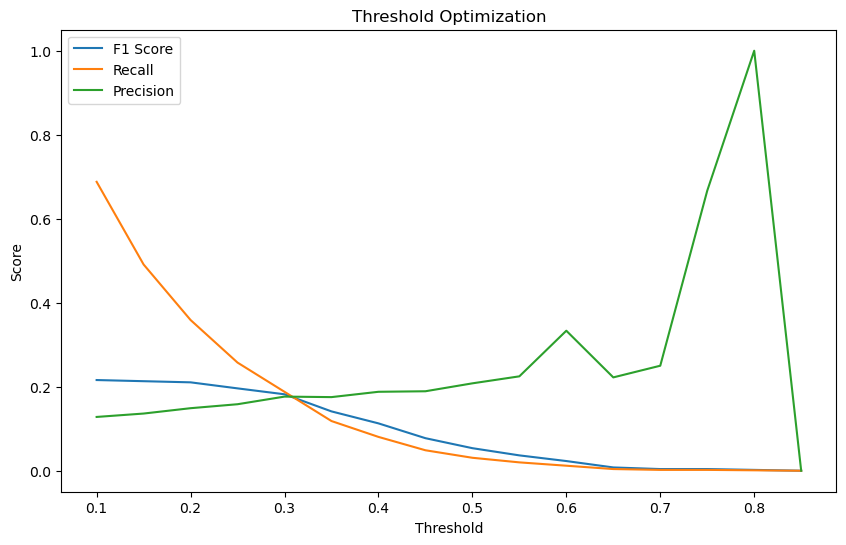

```python
thresholds = np.arange(0.1, 0.9, 0.05)

f1_scores = []
recalls = []
precisions = []

for t in thresholds:
    y_pred = (y_proba >= t).astype(int)
    f1_scores.append(f1_score(y_test, y_pred))
    recalls.append(recall_score(y_test, y_pred))
    precisions.append(precision_score(y_test, y_pred))

plt.figure(figsize=(10,6))
plt.plot(thresholds, f1_scores, label='F1 Score')
plt.plot(thresholds, recalls, label='Recall')
plt.plot(thresholds, precisions, label='Precision')

plt.xlabel("Threshold")
plt.ylabel("Score")
plt.title("Threshold Optimization")
plt.legend()
plt.show()
```

### Business Recommendations

1. Deploy the model in a real-time transaction monitoring system to flag high-risk transactions instantly.
2. Implement step-up authentication (OTP, biometric verification) for transactions classified as high risk.
3. Continuously retrain the model with new transaction data to adapt to evolving fraud patterns.
4. Integrate the model with rule-based systems to improve precision and reduce false positives.
5. Monitor key metrics such as recall and false positive rate to balance customer experience and fraud prevention.